# Using Machine Learning to Predict Proper Execution of Barbell Exercise

by: Ryan M. Swartz

# Executive Summary

In a recent experiment carried out by researchers at Groupware @ LES<sup>1</sup>, six subjects wore accelerometers on their the belt, forearm, arm, and a dumbell while performing a weight training exercise either with correct or incorrect form. I split this data into a training set and a test set with the object of building and testing a machine learning model to classify the activity as correct or incorrect based on only the readings of the accelerometers. With this data, the trained model demonstrated an out-of-sample accuracy of 99.2% using a random sub-sampling cross-validation approach to test, and correctly predicted execution class on 20 of 20 test cases provided as a final check on the model.

# Data Processing

I executed a several step process, detailed below, to segment the data and prepare it for the model building process:

**Step 1**: Load any R packages required for the analysis.

```r
library(vcd)
library(caret)
library(gbm)
library(randomForest)
library(e1071)
```

**Step 2**: Download the source data and create appropriate R objects.

```r
train.URL <- "http://d396qusza40orc.cloudfront.net/predmachlearn/pml-training.csv"
test.URL <- "http://d396qusza40orc.cloudfront.net/predmachlearn/pml-testing.csv"
training <- read.table(train.URL, header = TRUE, sep = ",", dec = ",",
                       na.strings = c("NA", ""))
testing <- read.table(test.URL, header = TRUE, sep = ",", dec = ",",
                      na.strings = c("NA", ""))
```

**Step 3**: After inspection of the training data with the `str()` function, I cleaned the data (both training and test sets) by removing the predictors with ‘NA’ values among their observations and subsetting the data to the outcome and the measurements from the accelerometers. Also, I converted any measurements inadvertently stored as `factor` to `numeric`.

```r
str(training)
```

```r
## remove significantly (>25%) NA variables from training set
## (and use that to drive test set cleaning later)
training.na.sum <- colSums(is.na(training))
training.remove <- which(training.na.sum > (0.25 * nrow(training)))
training.clean <- training[, -training.remove]
## subset both the training and test sets to variables from accelerometers and
## necessary identities (i.e., excluding row reference 'X')
var.names <- names(training.clean[c(60, 2, 8:59)])
training.clean <- subset(training.clean, select = var.names)
testing.clean <- subset(testing, select = names(testing) %in% var.names)
## convert the measurements of class 'factor' and 'integer' to 'numeric' for
## training and test sets
for (i in 3:54) {
      if (class(training.clean[, i]) == "factor")
            training.clean[, i] <- as.numeric(as.character(training.clean[, i]))
      else if (class(training.clean[, i]) == "integer")
            training.clean[, i] <- as.numeric(training.clean[, i])
      else
            training.clean[, i] <- training.clean[, i]
}
for (i in 2:53) {
      if (class(testing.clean[, i]) == "factor")
            testing.clean[, i] <- as.numeric(as.character(testing.clean[, i]))
      else if (class(testing.clean[, i]) == "integer")
            testing.clean[, i] <- as.numeric(testing.clean[, i])
      else
            testing.clean[, i] <- testing.clean[, i]
}
```

**Step 4**: I split the original training data into two sets based on a 75% random sub-sampling scheme to enable cross-validation of the model options and insight to select the best approach before the final test on the `classe` variable. `classe` indicates correct or incorrect execution of the exercise with codes A through E, where A indicates a correct execution, while the others classify a variety of improper executions. For full details, please see Reference 1.

```r
set.seed(19428)
in.train <- createDataPartition(y = training.clean$classe, p = 0.75, list = FALSE)
training.clean.cv <- training.clean[in.train, ]
testing.clean.cv <- training.clean[-in.train, ]
```

**Step 5**: In this portion of the analysis, I created two options for the sets of predictors used in the models for evaluation of the better method..

*Option 1*: Removing Near Zero Covariates (NZC) identifies those predictors with near zero covariance to limit the predictors to just those that are likely to be good.

```r
set.seed(19428)
nzc.ni <- nearZeroVar(training.clean.cv, saveMetrics = TRUE)
training.clean.cv.nzc <- training.clean.cv[, colnames(training.clean.cv) %in%
                                             rownames(nzc.ni)[nzc.ni$nzv == FALSE]]
testing.clean.cv.nzc <- testing.clean.cv[, colnames(testing.clean.cv) %in%
                                           rownames(nzc.ni)[nzc.ni$nzv == FALSE]]
```

As it turns out, NZC does not remove any predictors from consideration as compared to the training set; therefore, all predictors in the training data are sufficiently variable in comparison to each other by this measure.

*Option 2*: To consider another way to select predictors, Principal Components Analysis (PCA) is used to collapse the clean training data’s predictors to weighted combinations. This PCA set will be used to train two models and compare the performance of those models against that of models trained with the clean training set, allowing me to determine which method of predictor selection is best for this problem.

```r
set.seed(19428)
pre.proc.cv <- preProcess(training.clean.cv[, 3:54], method = "pca", thresh = 0.8)
## create training data of PCA predictors
training.clean.cv.pca <- predict(pre.proc.cv, training.clean.cv[, 3:54])
training.clean.cv.pca <- cbind(training.clean.cv[, 1:2], training.clean.cv.pca)
## create testing data of PCA predictors
testing.clean.cv.pca <- predict(pre.proc.cv, testing.clean.cv[, 3:54])
testing.clean.cv.pca <- cbind(testing.clean.cv[, 1:2], testing.clean.cv.pca)
```

Lastly, while the above considers the numerical data coming from the accelerometers, I did a simple exploration of the relationship between the subject performing the exercise and the classification to determine if this factor should be a predictor along with the numerical data from the accelerometers.

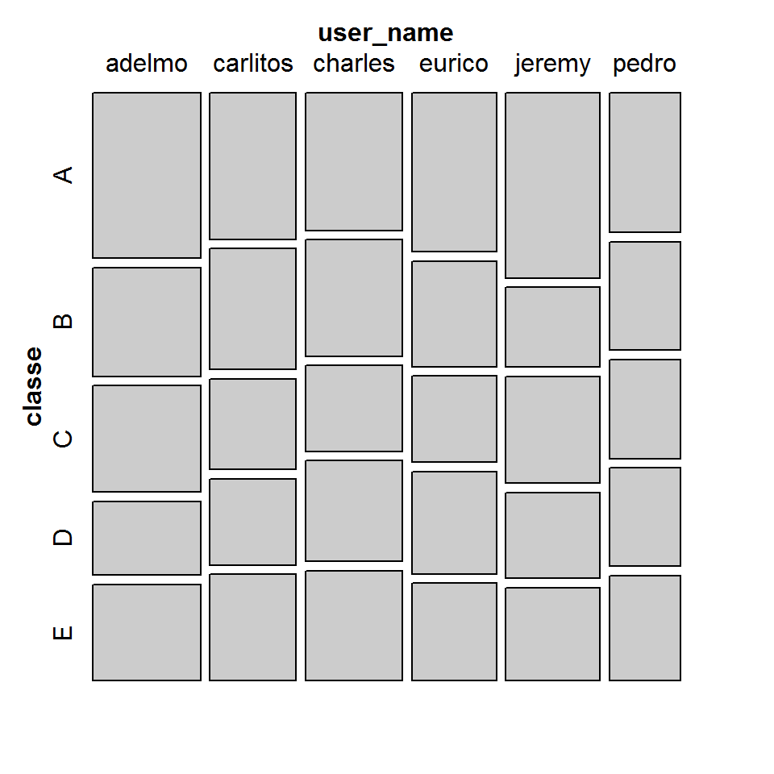

```r
mosaic.plot <- mosaic(~ classe | user_name, data = training.clean.cv, split_vertical = TRUE)
```

**Fig. 1**: Mosaic plot of each subject `user_name` and their exercise classification `classe`

With this mosaic plot, we can see that there is a fair amount of variability in the subjects’ abilities to perform the exercise, so I will definitely include this variable as a predictor for both the clean training data and PCA data.

# Model Construction and Error Measurement

```r
## remove objects no longer needed to free memory space
rm(nzc.ni)
rm(training.clean.cv.nzc)
rm(testning.clean.cv.nzc)
```

```r
set.seed(19428)
## Model 1: training data with all predictors, boosting approach
mod.fit.all.b <- train(classe ~ ., method = "gbm", data = training.clean.cv,
                       verbose = FALSE)
```

```r
set.seed(19428)
## Model 2: training data with all predictors, random forest model approach
mod.fit.all.rf <- train(classe ~ ., method = "rf", data = training.clean.cv,
                        prox = TRUE)
```

```r
set.seed(19428)
## Model 3: PCA data, boosting approach
mod.fit.pca.b <- train(classe ~ ., method = "gbm", data = training.clean.cv.pca,
                       verbose = FALSE)
```

```r
set.seed(19428)
## Model 4: PCA data, random forest approach
mod.fit.pca.rf <- train(classe ~ ., method = "rf", data = training.clean.cv.pca,
                        prox = TRUE)
```

With the completion of four different models, I set-up the cross validation portion of model building. Recall that I created a training set and validation set of data from the original training corpus with a 75% split. With the validation set, I determined estimates for the out-of-sample error for each model option and selected the approach with the lowest error as the final model on which to predict with the test set.

```r
## Model 1: predictions and confusion matrices
pred.fit.1.is <- predict(mod.fit.all.b, newdata = training.clean.cv)
pred.fit.1 <- predict(mod.fit.all.b, newdata = testing.clean.cv)
cm.fit.1.is <- confusionMatrix(pred.fit.1.is, training.clean.cv$classe)
cm.fit.1 <- confusionMatrix(pred.fit.1, testing.clean.cv$classe)
## Model 2: predictions and confusion matrices
pred.fit.2.is <- predict(mod.fit.all.rf, newdata = training.clean.cv)
pred.fit.2 <- predict(mod.fit.all.rf, newdata = testing.clean.cv)
cm.fit.2.is <- confusionMatrix(pred.fit.2.is, training.clean.cv$classe)
cm.fit.2 <- confusionMatrix(pred.fit.2, testing.clean.cv$classe)
## Model 3: predictions and confusion matrices
pred.fit.3.is <- predict(mod.fit.pca.b, newdata = training.clean.cv.pca)
pred.fit.3 <- predict(mod.fit.pca.b, newdata = testing.clean.cv.pca)
cm.fit.3.is <- confusionMatrix(pred.fit.3.is, training.clean.cv.pca$classe)
cm.fit.3 <- confusionMatrix(pred.fit.3, testing.clean.cv.pca$classe)
## Model 4: predictions and confusion matrices
pred.fit.4.is <- predict(mod.fit.pca.rf, newdata = training.clean.cv.pca)
pred.fit.4 <- predict(mod.fit.pca.rf, newdata = testing.clean.cv.pca)
cm.fit.4.is <- confusionMatrix(pred.fit.4.is, training.clean.cv.pca$classe)
cm.fit.4 <- confusionMatrix(pred.fit.4, testing.clean.cv.pca$classe)
```

Having built the models and performed cross validation, the estimates for out-of-sample error and kappa are as follows for each:

[output not shown]

With this cross validation, the most accurate approach is to use all variables in the clean training set to train a random forest model. We note the in-sample accuracy of this model approach to be 100%, which is of course an over-estimate of the out-of-sample accuracy of 99.2%. As a final test, I run the model against the provided testing set to evaluate the model on 20 test cases and write those results to text files in the working directory.

```r
final.test.results <- predict(mod.fit.all.rf, newdata = testing.clean)
PMLWriteFiles <- function(x){
      n <- length(x)
      for(i in 1:n){
         filename <- paste0("problem_id_", i, ".txt")
         write.table(x[i], file = filename, quote = FALSE, row.names = FALSE,
                      col.names = FALSE)
      }
}
PMLWriteFiles(final.test.results)
```

# Results

In this analysis, I determined the best approach to building a classification model to evaluate exercise performance using accelerometer data as using all relevant predictors among this data to train a random forest model. Cross validation showed this model to have the best out-of-sample accuracy at 99.2%. The possibilities for such a model are many, including use in devices to measure the movements of any physcial activity that requires precision to determine how well that goal is achieved (e.g., athletes in training exercises or competition). To further improve upon the model, future study could try different machine learning approaches (such as scalable vector machines) or retaining a greater portion of the readings from the acclerometers. In this analysis, much of the original training data was not included in the model because it was missing; future efforts would benefit from either correcting the accelerometers to report this data, or imputing a portion of the data when there is enough variable data to do so.

# References

1. Velloso, E.; Bulling, A.; Gellersen, H.; Ugulino, W.; Fuks, H. [Qualitative Activity Recognition of Weight Lifting Exercises](http://groupware.les.inf.puc-rio.br/work.jsf?p1=11201). Proceedings of 4th International Conference in Cooperation with SIGCHI (Augmented Human ’13) . Stuttgart, Germany: ACM SIGCHI, 2013.